# Effects of Flight Characteristics on Their Probability of Being Cancelled, Diverted or Delayed

## Investigation Overview

In this investigation, I wanted to look at the characteristics of flights that could be used to predict their flight status. The main focus was on different carriers, different airports, distance of the flight, airtime, and day of the week.

## Dataset Overview

The data consisted of flight_status and attributes of approximately 2.4 million US flights in 2008. The attributes included delay compared to estimated arrival and departure, as well as additional measurements such as flight distance, origin and destination airport, date, and day of the week.

## Distribution of Flight Statuses

Flights in this dataset are mostly On Time/Early or Delayed, with 1,734,538 falling into the former category and 584,883 falling into the latter. Cancelled and Diverted flights are much less common in this dataset respectively: 64,442 and 5,654.

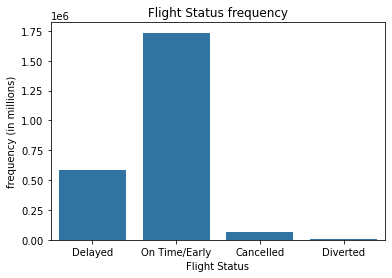

```python
flights['flight_status'] = np.where(flights.Cancelled, 'Cancelled', np.where(flights.Diverted, 'Diverted', np.where(flights.ArrDelay >= 15, 'Delayed', 'On Time/Early')))
base_color = sb.color_palette()[0]
sb.countplot(data = flights, x = 'flight_status', color = base_color)
plt.xlabel('Flight Status')
plt.ylabel('frequency (in millions)')
plt.title('Flight Status frequency');
```

## Distribution of Carriers

This dataset featured 20 unique carriers, which range in the number of flights they offer. The real outlier in this barplot is the carrier WN, which has close to double the flights (~400,000) than the next most frequent carrier in this dataset.

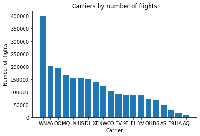

```python
plt.bar(flights.UniqueCarrier.value_counts().index, flights.UniqueCarrier.value_counts().values)
plt.xlabel('Carrier')
plt.ylabel('Number of flights')
plt.title('Carriers by number of flights');
```

## Distribution of Days of the Week

For Days of the Week, I decided to chart their relative frequency. I found that Saturday and Sunday have flights less frequently, with Saturday contributing over 2.5% less to overall flight traffic than the weekday average.

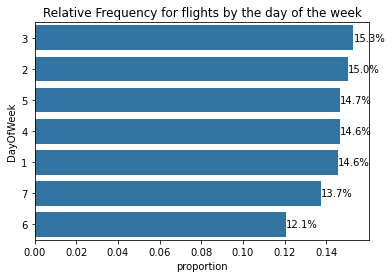

```python
sb.countplot(data = flights, y = 'DayOfWeek', color = base_color, order = flights.DayOfWeek.value_counts().index)
plt.xticks(tick_props * n_flights, tick_names)
plt.xlabel('proportion')
plt.title('Relative Frequency for flights by the day of the week')
for i in range(flights.DayOfWeek.value_counts().shape[0]):
    count = flights.DayOfWeek.value_counts().values[i]
    pct_string = '{:0.1f}%'.format(100*count/n_flights)
    plt.text(count+1, i, pct_string, va = 'center');
```

## Distribution of Distance

The distribution of flight distance in this dataset is roughly normal when a log scale is applied. In general, there are far fewer long distance flights than those short in distance

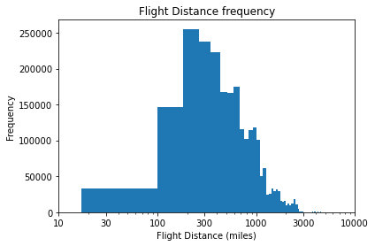

```python
plt.hist(flights.Distance, bins = 60)
plt.xscale('log')
ticks = [10, 30, 100, 300, 1000, 3000, 10000]
labels = ['{}'.format(v) for v in ticks]
plt.xticks(ticks, labels)
plt.xlabel('Flight Distance (miles)')
plt.ylabel('Frequency')
plt.title('Flight Distance frequency');
```

## Flight Status vs. Distance

I used a violin plot to show the different distributions of distances for flights of each flight status. Diverted flights are the most consistently far flights, which makes sense, as they may be diverted because the pilot is running out of fuel or needs and emergency place to land on the long journey

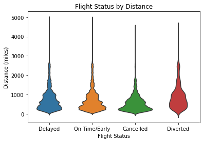

```python
sb.violinplot(data = flights, x = 'flight_status', y = 'Distance', inner = None)
plt.xlabel('Flight Status')
plt.ylabel('Distance (miles)')
plt.title('Flight Status by Distance');
```

## Airport proportion of flights Cancelled/Diverted/Delayed vs. airport total number of flights

I took all the airports in the dataset and calculated the proportion of flights that don't land On Time/ Early. The best and worst airports in terms of proportion of flights Cancelled/Diverted/Delayed tend to be smaller, while bigger airports typically have a mid-ranged value.

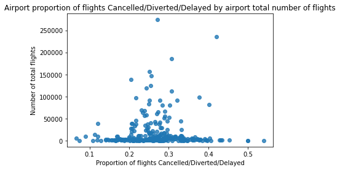

```python
problem_flights_by_airport = flights.query('flight_status == "Cancelled" or flight_status == "Diverted" or flight_status == "Delayed"').Dest.value_counts() + flights.query('flight_status == "Cancelled" or flight_status == "Diverted" or flight_status == "Delayed"').Origin.value_counts()
pfba_prop = problem_flights_by_airport / (flights.Dest.value_counts() + flights.Origin.value_counts())
pfba_prop.dropna(inplace = True)
airport_props = pd.DataFrame(pfba_prop.sort_values(ascending = False))
airport_counts = flights.Origin.value_counts() + flights.Dest.value_counts()
airport_counts = pd.DataFrame(airport_counts)
airport_counts
airportdf = airport_counts.merge(airport_props, left_on = airport_counts.index, right_on = airport_props.index)
sb.regplot(data = airportdf, x = '0_y', y = '0_x', fit_reg = False)
plt.xlabel('Proportion of flights Cancelled/Diverted/Delayed')
plt.ylabel('Number of total flights')
plt.title('Airport proportion of flights Cancelled/Diverted/Delayed by airport total number of flights');
```

## Mean Arrival Delay time by Carrier

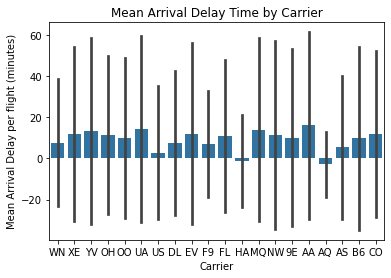

```python
sb.barplot(data = flights, x = 'UniqueCarrier', y = 'ArrDelay', ci = 'sd', color = base_color);
plt.xlabel('Carrier')
plt.ylabel('Mean Arrival Delay per flight (minutes)')
plt.title('Mean Arrival Delay Time by Carrier');
```

## Correlation between quantitative variables and flight status severity

In this section I create a new variable called flight status severity, which gives a numeric value for each flight status. On Time/Early = 0, Delayed = 1, Diverted = 2, and Cancelled = 3. While it appears that Arrival and Departure delay are positively correlated with flight status severity, the second correlation plot shows that this is only the case for delayed flights

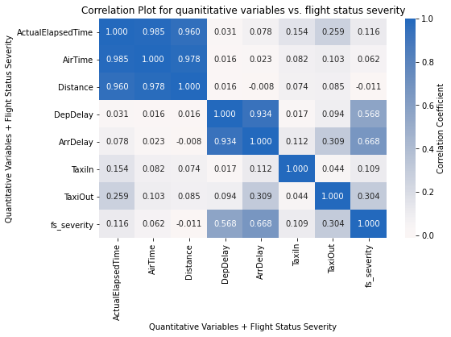

```python
flights['fs_severity'] = np.where(flights.flight_status == 'Cancelled', 3, np.where(flights.flight_status == 'Diverted', 2, np.where(flights.ArrDelay >= 15, 1, 0)))
plt.figure(figsize = [8, 5])
plt.title('Correlation Plot for quanititative variables vs. flight status severity')
plt.xlabel('Quantitative Variables + Flight Status Severity')
plt.ylabel('Quantitative Variables + Flight Status Severity')
num_vars = ['ActualElapsedTime', 'AirTime', 'Distance', 'DepDelay','ArrDelay', 'TaxiIn', 'TaxiOut', 'fs_severity']
heatmap = sb.heatmap(flights[num_vars].corr(), annot = True, fmt = '.3f',
           cmap = 'vlag_r', center = 0)
heatmap.set_xlabel('Quantitative Variables + Flight Status Severity')
heatmap.set_ylabel('Quantitative Variables + Flight Status Severity')
colorbar = heatmap.collections[0].colorbar
colorbar.set_label('Correlation Coefficient')
'Quantitative variables vs. Flight Status severity Correlation Plot'
plt.show()
```

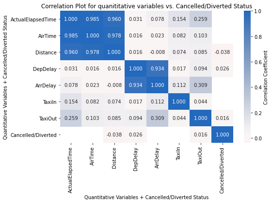

```python
flights['Cancelled/Diverted'] = np.where(flights.flight_status == 'Cancelled', 1, np.where(flights.flight_status == 'Diverted', 1, 0))
plt.figure(figsize = [8, 5])
plt.title('Correlation Plot for quanititative variables vs. Cancelled/Diverted Status')
plt.xlabel('Quantitative Variables + Cancelled/ Diverted Status')
plt.ylabel('Quantitative Variables + Cancelled/Diverted Status')
num_vars = ['ActualElapsedTime', 'AirTime', 'Distance', 'DepDelay','ArrDelay', 'TaxiIn', 'TaxiOut', 'Cancelled/Diverted']
heatmap = sb.heatmap(flights[num_vars].corr(), annot = True, fmt = '.3f',
           cmap = 'vlag_r', center = 0)
heatmap.set_xlabel('Quantitative Variables + Cancelled/Diverted Status')
heatmap.set_ylabel('Quantitative Variables + Cancelled/Diverted Status')
colorbar = heatmap.collections[0].colorbar
colorbar.set_label('Correlation Coefficient')
'Quantitative variables vs. Cancelled/Diverted Correlation Plot'
plt.show()
```

## Flight Status by Carrier

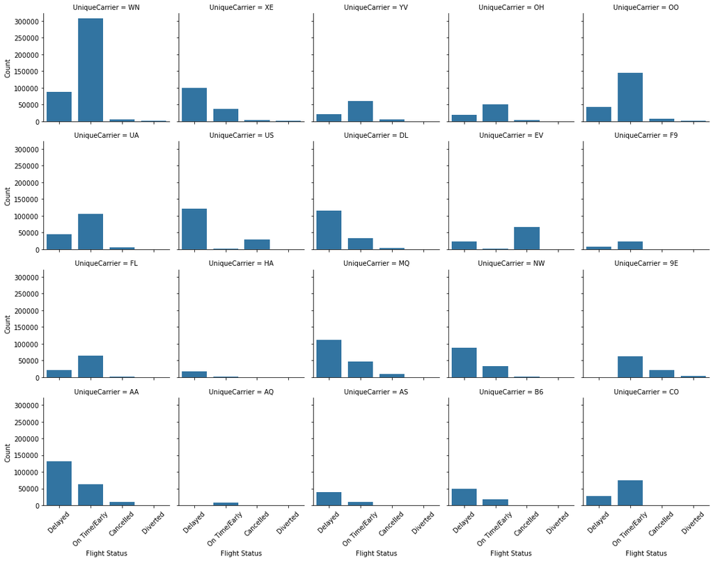

```python
g = sb.FacetGrid(data = flights, col = 'UniqueCarrier', col_wrap = 5)
[plt.setp(ax.get_xticklabels(), rotation=45) for ax in g.axes.flat]
g = g.map(sb.countplot, 'flight_status')
g.set_axis_labels("Flight Status", "Count");
```

## Distance vs. AirTime by Carrier and Flight Status

This plot shows the Distance/ Airtime of each flight for each Carrier, while the flight status is encoded by color. It seems that distance tends to not affect the flight status of a flight, but some carriers have interest quirks in their scatter plot. For example, Carrier HA has a series of long distance flights whose airtime was considerably longer than the proptional distance, so I might shy away from booking with them if I want to take a long distance flight.

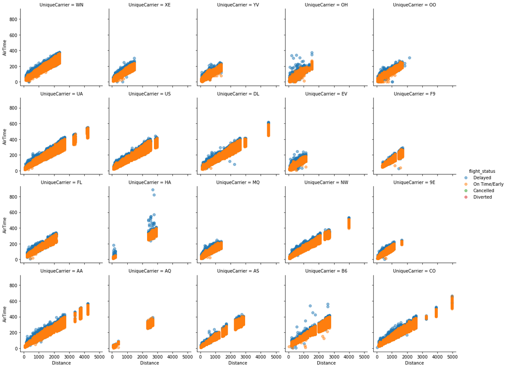

```python
g = sb.FacetGrid(data = flights, col = 'UniqueCarrier', col_wrap = 5, hue = 'flight_status')
g = g.map(plt.scatter, 'Distance', 'AirTime', alpha = .5)
g.add_legend();
```

## Conclusions

My biggest takeaway from this project is that carrier probably the most influential choice you have to determine whether or not your flight might get delayed, diverted, or cancelled. Some carriers, like WN have a great track record of getting the plane in on time, while others are less dependable. Other considerations, are flight distance, wherein long flights are slightly more likely to be diverted, and airport size, wherein large airports are more consistent in cancellations and small airports can vary quite a bit. Since distance distribution is normal based on a log scale, it may be hard to find a wide range of carriers for very long distance flights, since there are less of those flights offered in general